# Tasa de desempleo por país (2020-2023)

Bruno Delgado

2025-05-21

## Introducción

En este informe se analiza la evolución de la tasa de desempleo en distintos países del mundo entre los años 2020 y 2023, utilizando herramientas como R, Google Sheets y Tableau.

Este análisis busca responder preguntas clave como:

¿Cómo varía la tasa de desempleo entre regiones?

¿Qué impacto tuvieron los eventos globales recientes (como la pandemia de COVID-19)?

```r
## Cargar el CSV

Unemployement_data_Data <- read_csv("Unemployement_data - Data.csv", show_col_types = FALSE)

library(dplyr)

Unemployement_data_Data <- Unemployement_data_Data %>%
  mutate(across(`2020`:`2023`, as.character)) %>%
  mutate(across(`2020`:`2023`, ~na_if(., ".."))) %>%
  mutate(across(`2020`:`2023`, as.numeric))


##Remplazar ".." por NA y convertir a formato largo,

library(tidyr)

Unemployement_data_long <- pivot_longer(Unemployement_data_Data,cols = c("2020", "2021", "2022", "2023"),names_to = "Año", values_to ="TasaDesempleo" )

Unemployement_data_long$TasaDesempleo[Unemployement_data_long$TasaDesempleo == ".."] <- NA
Unemployement_data_long$TasaDesempleo <- as.numeric(Unemployement_data_long$TasaDesempleo)
Unemployement_data_long <- Unemployement_data_long %>%
  drop_na(TasaDesempleo)
```

## Gráfico

El siguiente gráfico toma de muestra únicamente 10 países para que se logre observar de manera clara la tendencia de la tasa de desempleo en diferentes países entre los años (2020 - 2023).

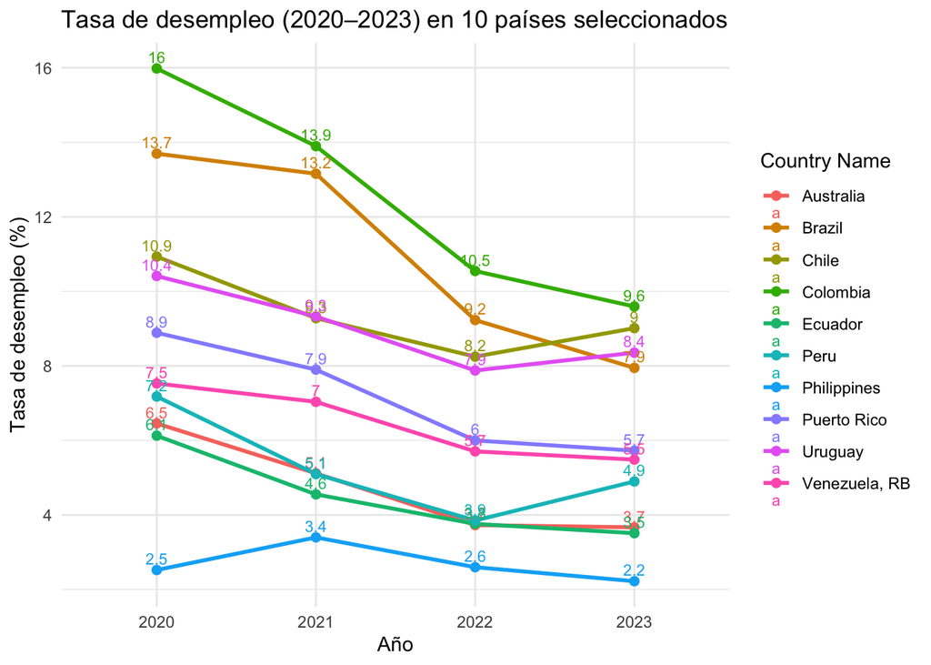

```r
ggplot(Unemployement_data_long %>% filter(`Country Name` %in% c("Brazil", "Chile", "Colombia","Ecuador", "Peru", "Uruguay","Venezuela, RB", "Australia", "Philippines","Puerto Rico")), aes(x = Año, y = TasaDesempleo, color = `Country Name`, group = `Country Name`)) +
  geom_line(linewidth = 1) +
  geom_point(size = 2) +
  geom_text(aes(label = round(TasaDesempleo, 1)), vjust = -0.5, size = 3) +
  labs(title = "Tasa de desempleo (2020–2023) en 10 países seleccionados",
       x = "Año",
       y = "Tasa de desempleo (%)") +
  theme_minimal()
```

## Conclusiones

Se observa una tendencia general de aumento del desempleo en 2020, seguida por una recuperación parcial en los años posteriores.

La evolución varía significativamente entre países, lo cual puede deberse a diferencias en políticas económicas, sector laboral, y acceso al trabajo remoto.

Este análisis establece una base para investigar la relación entre desempleo y sucesos importantes que han ocurrido desde la pandemia del COVID-19.

## Visualización interactiva

Puedes consultar el gráfico en Tableau o exportar los datos desde R para un análisis más interactivo.

[[Haz click aquí para ver el gráfico en Tableau]](https://public.tableau.com/views/TasadeDesempleoaNivelGlobal/Dashboard1?:language=en-US&:sid=&:redirect=auth&:display_count=n&:origin=viz_share_link)